# PRIMO LAVORO

Author

Vera Gelli

# CHE PAURA LA MATEMATICA

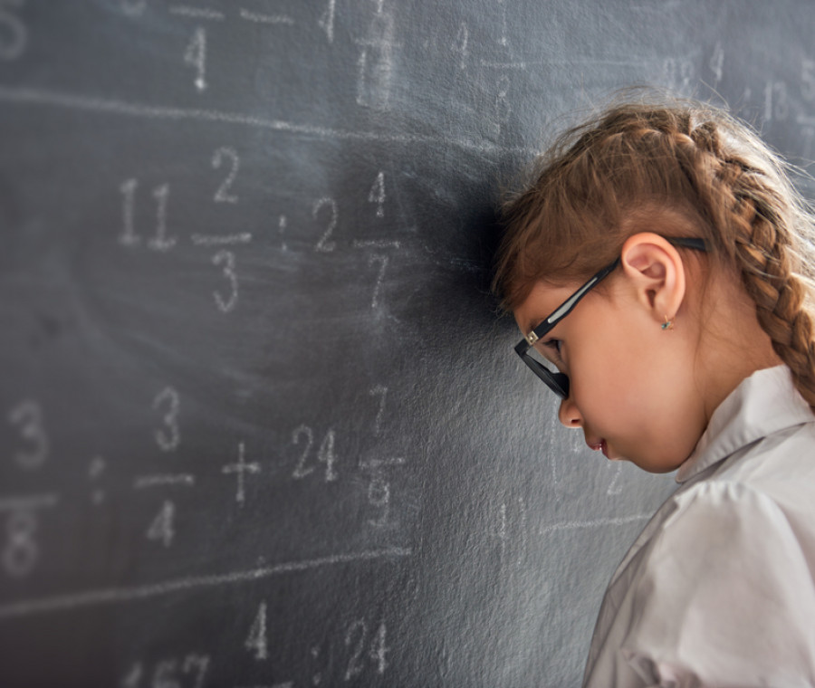

# Analisi:

### Prima di fare i test

#### PHOBIA

I punteggi ottenuti al test di autovalutazione di fobia per la matematica in base al genere sono 3.6 per le femmine e 2.93 per i maschi. Possiamo notare che in media le femmine si dicono più spavenate dalla matematica ripsetto ai maschi.

#### NUMERO DI CORSI DI MATEMATICA FREQUENTATI

In media le femmine frequentano 1.25 di matematica e i maschi 1.56, quindi mediamnete i maschi seguono più corsi di matematica rispetto alle femmine.

### Analizziamo la media dei risultati otteniti ai test in base alla differenza di genere

#### TEST DI MATEMATICA

Per quanto riguarda i test di matematica i maschi hanno ottenuto un punteggio di 28, leggermente minore rispetto alle femmine che mediamente hanno ottenuto 29.94.

#### TEST DI STATISTICA

Per quanto concerne il test di statistica i punteggi non sono differiscono di meno, e i maschi hanno ottenuto punteggi più alti; infatti il punteggio medio è di 6.93 e le femmine invece 6.81.

### Auto-valutaziobe battito cardiaco

Le femmine nella condizione normale mediamente le femmine hanno una frequenza cardiaca di 73.28 e i maschi 70.93. Questo indice fisologico è stato anche calcolato prima endopo il test: i maschi prima mediamnte hanno un battitto cardiaco di 72.74 e dopo invece di 71.93 e le femmine prima di 74.68 e dopo di 73.46, non mostrando nè nelle femmin nè nei maschi una variazione così significativa nel battito.

### punteggi test test sull’ansia

Per quanto riguarda i test sull’ansia fatti in condizione base, prima e dopo, le femmine mediamente in condizioni normali 19.23 , prima 20.56 e dopo 20.88. I maschi invece in condizioni normali 17.37, prima 18.28 e dopo 17.44.

# Analizziamo più nel dettaglio due variabili per confrontarle

Andiamo a vedere quanta variabilità c’è nei risultati del test di matematica nelle varie facoltà:

FACOLTÀ

Psicologia

Medicina

Biologia

Sociologia

Economia

MEDIA E DEVIAZIONE STANDARD

29.60

31.05

24.21

28.00

35.38

8.94

8.18

10.40

10.44

6.30

López-López et al. (2019)

## CITAZIONI

López-López, J. A., Davies, S. R., Caldwell, D. M., Churchill, R., Peters, T. J., Tallon, D., Dawson, S., Wu, Q., Li, J., Taylor, A., et al. (2019). The process and delivery of CBT for depression in adults: A systematic review and network meta-analysis. *Psychological Medicine*, *49*(12), 1937–1947.